# **Malaria Detection**

## **Data Description**

There are a total of 24,958 train and 2,600 test images (colored) that we have taken from microscopic images. These images are of the following categories:

**Parasitized:** The parasitized cells contain the Plasmodium parasite which causes malaria  
**Uninfected:** The uninfected cells are free of the Plasmodium parasites

### **Mount the Drive**

```python
#Mounting drive
from google.colab import drive
drive.mount('/content/drive')
```

### **Loading libraries**

```python
import numpy as np
import pandas as pd

import matplotlib.pyplot as plt
import seaborn as sns
import os

from PIL import Image
import zipfile
from sklearn.model_selection import train_test_split
from sklearn.metrics import classification_report, confusion_matrix
from sklearn.preprocessing import MinMaxScaler
import cv2
import tensorflow as tf
import keras
from tensorflow.keras.models import Sequential, Model
from tensorflow.keras.layers import Dense, Conv2D, MaxPooling2D, BatchNormalization, Activation, Input, LeakyReLU, Dropout, Flatten, GlobalAveragePooling2D
from tensorflow.keras import backend, regularizers
from tensorflow.keras.utils import to_categorical
from tensorflow.keras.optimizers import Adam, SGD, RMSprop
from tensorflow.keras.callbacks import EarlyStopping, ModelCheckpoint
from tensorflow.keras import losses, optimizers
from tensorflow.keras.preprocessing.image import load_img
from random import shuffle
from google.colab.patches import cv2_imshow
#Ignoring warnings
import warnings
warnings.filterwarnings("ignore")

#Removing the dislay limit
pd.set_option("display.max_columns", None)

pd.set_option("display.max_rows", 200)
```

### **Let us load the data**

**Note:**

- You must download the dataset from the link provided on Olympus and upload the same to your Google Drive. Then unzip the folder.

```python
#Storing path
path = '/content/drive/MyDrive/cell_images.zip'


#Extracting the data from the zip file
with zipfile.ZipFile(path, 'r') as zip_ref:
    zip_ref.extractall()
```

The extracted folder has different folders for train and test data will contain the different sizes of images for parasitized and uninfected cells within the respective folder name.

The size of all images must be the same and should be converted to 4D arrays so that they can be used as an input for the convolutional neural network. Also, we need to create the labels for both types of images to be able to train and test the model.

Let's do the same for the training data first and then we will use the same code for the test data as well.

```python
#Storing the path of train folder
train_dir = '/content/cell_images/train'

#Making sure that each image has the same size
SIZE = 64

#Storing training images in an emplty list after they are converted to array with NumPy
train_images = []

#Storing training labels in an empty list (0 - uninfected, 1 - parasitized)
train_labels = []
```

```python
for folder_name in ['/parasitized/', '/uninfected/']:

    #Registring the path of the folder
    images_path = os.listdir(train_dir + folder_name)

    for i, image_name in enumerate(images_path):

      try:

        #Opening images
        image = Image.open(train_dir + folder_name + image_name)

        #Resizing images to (64, 64)
        image = image.resize((SIZE, SIZE))

        #Converting images to arrays, and connecting them with the empty list already created
        train_images.append(np.array(image))

        #Creating labels
        if folder_name == '/parasitized/':

          train_labels.append(1)

        else:

          train_labels.append(0)

      except Exception:

        pass

#Converting list to arrays
train_images = np.array(train_images)
train_labels = np.array(train_labels)
```

```python
#Repeating the method with the testingdata

#Storing the path of train folder
test_dir = '/content/cell_images/test'

#Making sure that each image has the same size
SIZE = 64

#Storing training images in an emplty list after they are converted to array with NumPy
test_images = []

#Storing training labels in an empty list (0 - uninfected, 1 - parasitized)
test_labels = []
```

```python
for folder_name in ['/parasitized/', '/uninfected/']:

    #Registring the path of the folder
    images_path = os.listdir(test_dir + folder_name)

    for i, image_name in enumerate(images_path):

      try:

        #Opening images
        image = Image.open(test_dir + folder_name + image_name)

        #Resizing images to (64, 64)
        image = image.resize((SIZE, SIZE))

        #Converting images to arrays, and connecting them with the empty list already created
        test_images.append(np.array(image))

        #Creating labels
        if folder_name == '/parasitized/':

          test_labels.append(1)

        else:

          test_labels.append(0)

      except Exception:

        pass

#Converting list to arrays
test_images = np.array(test_images)
test_labels = np.array(test_labels)
```

### **Check the shape of train and test images**

```python
#Shape of train images
train_images.shape
```

```
(24958, 64, 64, 3)
```

```python
#Shape of test images
test_images.shape
```

```
(2600, 64, 64, 3)
```

### **Check the shape of train and test labels**

```python
#Shape of train labels
train_labels.shape
```

```
(24958,)
```

```python
#Shape of test labels
test_labels.shape
```

```
(2600,)
```

#### **Observations and insights:**

- train images : 24958 images, 64x64 pixels size, 3 rgb, which means that the pictures are in color
- test images : 2600 images, 64x64 pixels size, 3 rgb , which means that the pictures are in color
- train labels: 24958 images
- test labels: 2600 images

### **Check the minimum and maximum range of pixel values for train and test images**

```python
train_images.min(), train_images.max()
```

```
(0, 255)
```

```python
test_images.min(), test_images.max()
```

```
(0, 255)
```

#### **Observations and insights:**

The minimum and maximum number of pixels are 0 and 255 by train and test images

### **Count the number of values in both uninfected and parasitized**

```python
label_counts = pd.value_counts(train_labels)
print(label_counts)
```

```
1    12582
0    12376
Name: count, dtype: int64
```

12582 parasitized, 12376 uninfected

```python
label_counts = pd.value_counts(test_labels)
print(label_counts)
```

```
1    1300
0    1300
Name: count, dtype: int64
```

1300 parasitized, 1300 uninfected

### **Normalize the images**

```python
#Normalizing train and test images by dividing by 255, and converting them to float32
train_images = train_images.astype('float32') / 255.0
test_images = test_images.astype('float32') / 255.0
```

#### **Observations and insights:**

- Converting the pixel values to a 32 bit floating format. Machine learning models perform better with floating formats
- Dividing by 255 normalizes the pixel values, scaling from 0-255 to 0-1. This help the model to train faster

### **Plot to check if the data is balanced**

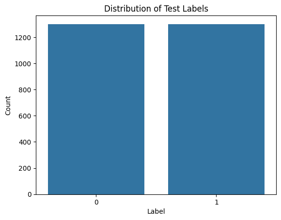

```python
count_plot = sns.countplot(x=test_labels)

# Customizing plot
plt.title('Distribution of Test Labels')
plt.xlabel('Label')
plt.ylabel('Count')

# Show the plot
plt.show()
```

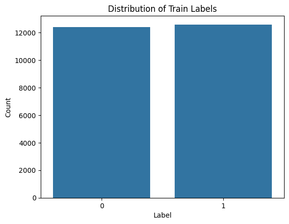

```python
count_plot = sns.countplot(x=train_labels)

# Customizing plot
plt.title('Distribution of Train Labels')
plt.xlabel('Label')
plt.ylabel('Count')

# Show the plot
plt.show()
```

#### **Observations and insights:**

- Data seems to be balanced

### **Data Exploration**

Let's visualize the images from the train data

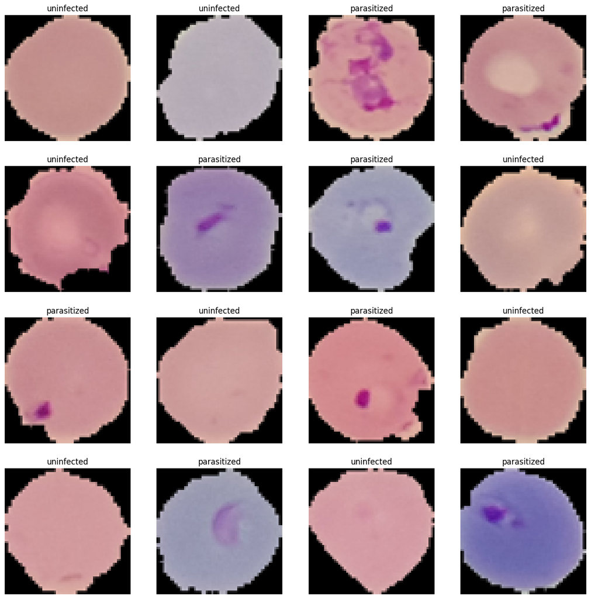

```python
np.random.seed(42)

plt.figure(1, figsize = (16 , 16))

for n in range(1, 17):

    plt.subplot(4, 4, n)

    index = int(np.random.randint(0, train_images.shape[0], 1))

    if train_labels[index] == 1:

        plt.title('parasitized')

    else:
        plt.title('uninfected')

    plt.imshow(train_images[index])

    plt.axis('off')
```

#### **Observations and insights:**

- There are red blood cells on the pictures, they are on of our blood components. The purple spots inside the red blood cells indicate the presence of Plasmodium parasites, meaning that they are the parasitized cells

### **Visualize the images with subplot(6, 6) and figsize = (12, 12)**

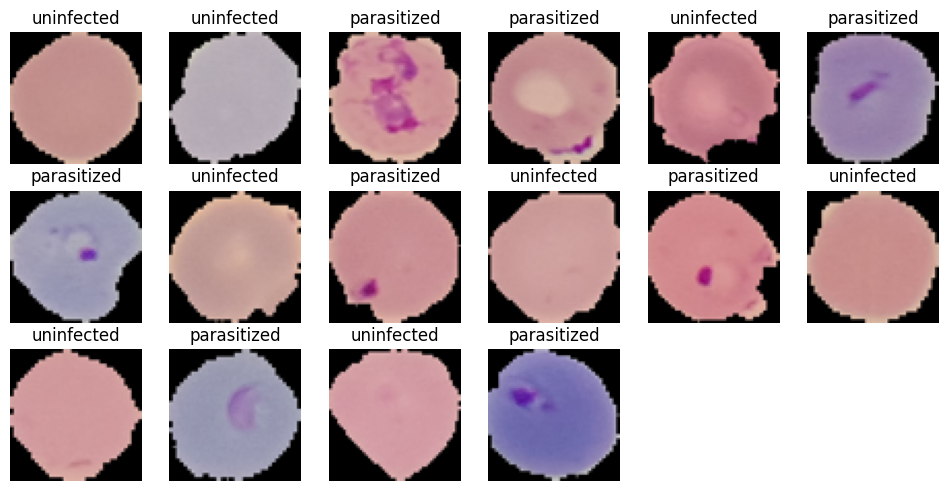

```python
np.random.seed(42)

plt.figure(1, figsize = (12 , 12))

for n in range(1, 17):

    plt.subplot(6, 6, n)

    index = int(np.random.randint(0, train_images.shape[0], 1))

    if train_labels[index] == 1:

        plt.title('parasitized')

    else:
        plt.title('uninfected')

    plt.imshow(train_images[index])

    plt.axis('off')
```

#### **Observations and insights:**

- There are red blood cells on the pictures, they are on of our blood components. The purple spots inside the red blood cells indicate the presence of Plasmodium parasites, meaning that they are the parasitized cells

### **Plotting the mean images for parasitized and uninfected**

```python
# Function to find the mean
def find_mean_img(full_mat, title):

    # Calculating the average
    mean_img = np.mean(full_mat, axis = 0)[0]

    # Reshaping
    plt.imshow(mean_img)

    plt.title(f'Average {title}')

    plt.axis('off')

    plt.show()

    return mean_img
```

**Mean image for parasitized**

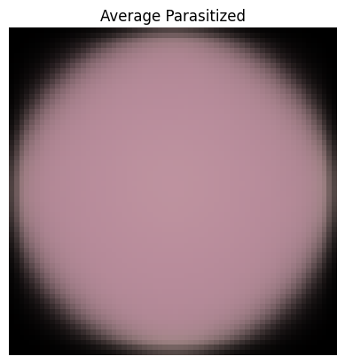

```python
parasitized_data = []

for img, label in zip(train_images, train_labels):

        if label == 1:

              parasitized_data.append([img])

parasitized_mean = find_mean_img(np.array(parasitized_data), 'Parasitized')
```

**Mean image for uninfected**

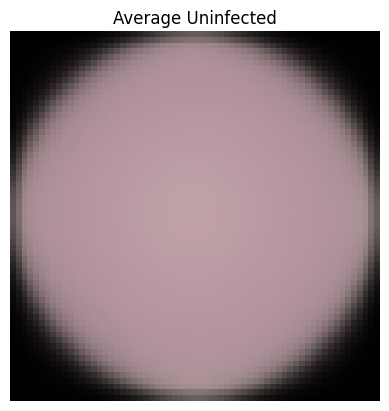

```python
uninfected_data = []
for img, label in zip(train_images, train_labels):

        if label == 0:

              uninfected_data.append([img])

uninfected_mean = find_mean_img(np.array(uninfected_data), 'Uninfected')
```

#### **Observations and insights:**

- The mean image for uninfected and parasitized seems to be really similar, therefore the location of the infection inside the cell could vary, just as the shape of the red blood cell.

### **Converting RGB to HSV of Images using OpenCV**

### **Converting the train data**

```python
gfx=[]

for i in np.arange(0, 100, 1):

  a = cv2.cvtColor(train_images[i], cv2.COLOR_BGR2HSV)

  gfx.append(a)

gfx = np.array(gfx)
```

[output not shown]

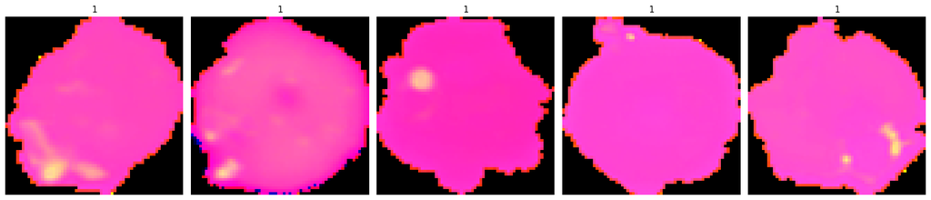

```python
viewimage = np.random.randint(1, 100, 5)

fig, ax = plt.subplots(1, 5, figsize = (18, 18))

for t, i in zip(range(5), viewimage):

  Title = train_labels[i]

  ax[t].set_title(Title)

  ax[t].imshow(gfx[i])

  ax[t].set_axis_off()

  fig.tight_layout()
```

### **Converting the test data**

```python
gfx=[]

for i in np.arange(0, 100, 1):

  a = cv2.cvtColor(test_images[i], cv2.COLOR_BGR2HSV)

  gfx.append(a)

gfx = np.array(gfx)
```

[output not shown]

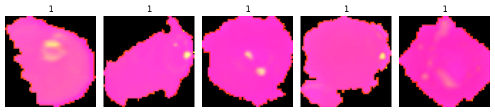

```python
viewimage = np.random.randint(1, 100, 5)

fig, ax = plt.subplots(1, 5, figsize = (10, 10))

for t, i in zip(range(5), viewimage):

  Title = test_labels[i]

  ax[t].set_title(Title)

  ax[t].imshow(gfx[i])

  ax[t].set_axis_off()

  fig.tight_layout()
```

#### **Observations and insights:**

- After converting the images to HSV the colors seem to be more intense. Maybe it helps the model to recognize parasitized cells better

### **Processing Images using Gaussian Blurring**

### **Gaussian Blurring on train data**

```python
gbx = []

for i in np.arange(0, 100, 1):

  b = cv2.GaussianBlur(train_images[i], (5, 5), 0)

  gbx.append(b)

gbx = np.array(gbx)
```

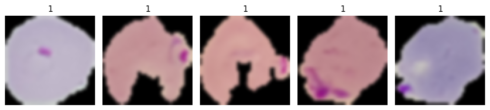

```python
viewimage = np.random.randint(1, 100, 5)

fig, ax = plt.subplots(1, 5, figsize = (10, 10))

for t, i in zip(range(5), viewimage):

  Title = train_labels[i]

  ax[t].set_title(Title)


  ax[t].imshow(gbx[i])

  ax[t].set_axis_off()

  fig.tight_layout()
```

### **Gaussian Blurring on test data**

```python
gbx = []

for i in np.arange(0, 100, 1):

  b = cv2.GaussianBlur(test_images[i], (5, 5), 0)

  gbx.append(b)

gbx = np.array(gbx)
```

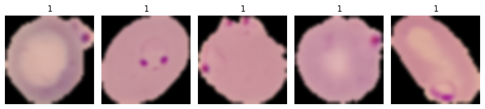

```python
viewimage = np.random.randint(1, 100, 5)

fig, ax = plt.subplots(1, 5, figsize = (10, 10))

for t, i in zip(range(5), viewimage):

  Title = test_labels[i]

  ax[t].set_title(Title)


  ax[t].imshow(gbx[i])

  ax[t].set_axis_off()

  fig.tight_layout()
```

#### **Observations and insights:*

- After applying Gaussian Blurring, we reduced noise and our images are smoothed, the edges of the cell are easier to differentiate.

**Think About It:** Would blurring help us for this problem statement in any way? What else can we try?

- We could try data augmentization techniques, or some kind of noise reduction

## **Model Building**

### **Base Model**

**Note:** The Base Model has been fully built and evaluated with all outputs shown to give an idea about the process of the creation and evaluation of the performance of a CNN architecture. A similar process can be followed in iterating to build better-performing CNN architectures.

### **Importing the required libraries for building and training our Model**

```python
#I did at the beginning
```

#### **One Hot Encoding the train and test labels**

```python
train_labels = to_categorical(train_labels, 2)
test_labels = to_categorical(test_labels, 2)
```

### **Building the model**

```python
from tensorflow.keras import backend
backend.clear_session()

np.random.seed(42)
import random
random.seed(42)
tf.random.set_seed(42)
```

```python
model = Sequential()

model.add(Conv2D(filters = 32, kernel_size = 2, padding = "same", activation = "relu", input_shape = (64, 64, 3)))

model.add(MaxPooling2D(pool_size = 2))

model.add(Dropout(0.2))

model.add(Conv2D(filters = 32, kernel_size = 2, padding = "same", activation = "relu"))

model.add(MaxPooling2D(pool_size = 2))

model.add(Dropout(0.2))

model.add(Conv2D(filters = 32, kernel_size = 2, padding = "same", activation = "relu"))

model.add(MaxPooling2D(pool_size = 2))

model.add(Dropout(0.2))

model.add(Flatten())

model.add(Dense(512, activation = "relu"))

model.add(Dropout(0.4))

model.add(Dense(2, activation = "softmax"))

model.summary()
```

```
Model: "sequential"
```

```
┏━━━━━━━━━━━━━━━━━━━━━━━━━━━━━━━━━━━━━━┳━━━━━━━━━━━━━━━━━━━━━━━━━━━━━┳━━━━━━━━━━━━━━━━━┓
┃ Layer (type)                         ┃ Output Shape                ┃         Param # ┃
┡━━━━━━━━━━━━━━━━━━━━━━━━━━━━━━━━━━━━━━╇━━━━━━━━━━━━━━━━━━━━━━━━━━━━━╇━━━━━━━━━━━━━━━━━┩
│ conv2d (Conv2D)                      │ (None, 64, 64, 32)          │             416 │
├──────────────────────────────────────┼─────────────────────────────┼─────────────────┤
│ max_pooling2d (MaxPooling2D)         │ (None, 32, 32, 32)          │               0 │
├──────────────────────────────────────┼─────────────────────────────┼─────────────────┤
│ dropout (Dropout)                    │ (None, 32, 32, 32)          │               0 │
├──────────────────────────────────────┼─────────────────────────────┼─────────────────┤
│ conv2d_1 (Conv2D)                    │ (None, 32, 32, 32)          │           4,128 │
├──────────────────────────────────────┼─────────────────────────────┼─────────────────┤
│ max_pooling2d_1 (MaxPooling2D)       │ (None, 16, 16, 32)          │               0 │
├──────────────────────────────────────┼─────────────────────────────┼─────────────────┤
│ dropout_1 (Dropout)                  │ (None, 16, 16, 32)          │               0 │
├──────────────────────────────────────┼─────────────────────────────┼─────────────────┤
│ conv2d_2 (Conv2D)                    │ (None, 16, 16, 32)          │           4,128 │
├──────────────────────────────────────┼─────────────────────────────┼─────────────────┤
│ max_pooling2d_2 (MaxPooling2D)       │ (None, 8, 8, 32)            │               0 │
├──────────────────────────────────────┼─────────────────────────────┼─────────────────┤
│ dropout_2 (Dropout)                  │ (None, 8, 8, 32)            │               0 │
├──────────────────────────────────────┼─────────────────────────────┼─────────────────┤
│ flatten (Flatten)                    │ (None, 2048)                │               0 │
├──────────────────────────────────────┼─────────────────────────────┼─────────────────┤
│ dense (Dense)                        │ (None, 512)                 │       1,049,088 │
├──────────────────────────────────────┼─────────────────────────────┼─────────────────┤
│ dropout_3 (Dropout)                  │ (None, 512)                 │               0 │
├──────────────────────────────────────┼─────────────────────────────┼─────────────────┤
│ dense_1 (Dense)                      │ (None, 2)                   │           1,026 │
└──────────────────────────────────────┴─────────────────────────────┴─────────────────┘
```

```
 Total params: 1,058,786 (4.04 MB)
```

```
 Trainable params: 1,058,786 (4.04 MB)
```

```
 Non-trainable params: 0 (0.00 B)
```

### **Compiling the model**

```python
model.compile(loss = 'binary_crossentropy', optimizer = 'adam', metrics = ['accuracy'])
```

**Using Callbacks**

```python
callbacks = [EarlyStopping(monitor = 'val_loss', patience = 2),
             ModelCheckpoint('.mdl_wts.keras', monitor = 'val_loss', save_best_only = True)]
```

**Fit and train our Model**

```python
history = model.fit(train_images, train_labels, batch_size = 32, callbacks = callbacks, validation_split = 0.2, epochs = 20, verbose = 1)
```

```
624/624 ━━━━━━━━━━━━━━━━━━━━ 18s 15ms/step - accuracy: 0.7071 - loss: 0.5504 - val_accuracy: 0.9645 - val_loss: 0.1430
624/624 ━━━━━━━━━━━━━━━━━━━━ 4s 7ms/step - accuracy: 0.9529 - loss: 0.1298 - val_accuracy: 0.9696 - val_loss: 0.2424
624/624 ━━━━━━━━━━━━━━━━━━━━ 4s 6ms/step - accuracy: 0.9645 - loss: 0.1070 - val_accuracy: 0.9874 - val_loss: 0.0894
624/624 ━━━━━━━━━━━━━━━━━━━━ 5s 6ms/step - accuracy: 0.9717 - loss: 0.0882 - val_accuracy: 0.9822 - val_loss: 0.0765
624/624 ━━━━━━━━━━━━━━━━━━━━ 5s 7ms/step - accuracy: 0.9745 - loss: 0.0764 - val_accuracy: 0.9834 - val_loss: 0.0682
624/624 ━━━━━━━━━━━━━━━━━━━━ 5s 6ms/step - accuracy: 0.9754 - loss: 0.0724 - val_accuracy: 0.9836 - val_loss: 0.0643
624/624 ━━━━━━━━━━━━━━━━━━━━ 3s 5ms/step - accuracy: 0.9755 - loss: 0.0743 - val_accuracy: 0.9784 - val_loss: 0.0884
624/624 ━━━━━━━━━━━━━━━━━━━━ 7s 8ms/step - accuracy: 0.9766 - loss: 0.0711 - val_accuracy: 0.9818 - val_loss: 0.0611
624/624 ━━━━━━━━━━━━━━━━━━━━ 10s 7ms/step - accuracy: 0.9781 - loss: 0.0655 - val_accuracy: 0.9752 - val_loss: 0.0757
624/624 ━━━━━━━━━━━━━━━━━━━━ 5s 7ms/step - accuracy: 0.9760 - loss: 0.0652 - val_accuracy: 0.9742 - val_loss: 0.0742
```

### **Evaluating the model on test data**

```python
accuracy = model.evaluate(test_images, test_labels, verbose = 1)
print('\n', 'Test_Accuracy:-', accuracy[1])
```

```
82/82 ━━━━━━━━━━━━━━━━━━━━ 1s 10ms/step - accuracy: 0.9880 - loss: 0.0446

 Test_Accuracy:- 0.9834615588188171
```

**Plotting the confusion matrix**

```
82/82 ━━━━━━━━━━━━━━━━━━━━ 1s 5ms/step
              precision    recall  f1-score   support

           0       0.99      0.98      0.98      1300
           1       0.98      0.99      0.98      1300

    accuracy                           0.98      2600
   macro avg       0.98      0.98      0.98      2600
weighted avg       0.98      0.98      0.98      2600
```

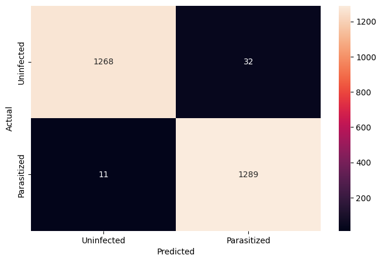

```python
pred = model.predict(test_images)
pred = np.argmax(pred, axis = 1)
y_true = np.argmax(test_labels, axis = 1)

#Print classification report
report_model = classification_report(y_true, pred, output_dict=True)
print(classification_report(y_true, pred))

#Plotting the heatmap
cm = confusion_matrix(y_true, pred)
plt.figure(figsize = (8, 5))
sns.heatmap(cm, annot = True,  fmt = '.0f', xticklabels = ['Uninfected', 'Parasitized'], yticklabels =['Uninfected', 'Parasitized'] )
plt.ylabel('Actual')
plt.xlabel('Predicted')
plt.show()
```

**Plotting the train and validation curves**

```python
def plot_accuracy(history):

    N = len(history.history["accuracy"])

    plt.figure(figsize = (7, 7))

    plt.plot(np.arange(0, N), history.history["accuracy"], label = "Training accuracy")

    plt.plot(np.arange(0, N), history.history["val_accuracy"], label = "Validation accuracy")

    plt.title('Training and Validation Accuracy')

    plt.xlabel("Epochs")

    plt.ylabel("Accuracy")

    plt.legend(loc="upper left")
```

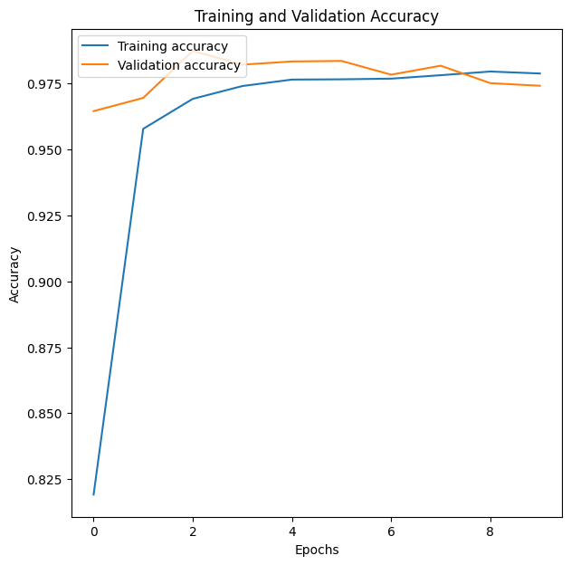

```python
plot_accuracy(history)
```

So now let's try to build another model with few more add on layers and try to check if we can try to improve the model. Therefore try to build a model by adding few layers if required and altering the activation functions.

### **Model 1**

#### **Trying to improve the performance of our model by adding new layers**

```python
backend.clear_session()

np.random.seed(42)
import random
random.seed(42)
tf.random.set_seed(42)
```

### **Building the Model**

```python
model1 = Sequential()

model1.add(Conv2D(filters = 64, kernel_size = 2, padding = "same", activation = "relu", input_shape = (64, 64, 3)))

model1.add(BatchNormalization())

model1.add(MaxPooling2D(pool_size = 2))

model1.add(Dropout(0.2))

model1.add(Conv2D(filters = 32, kernel_size = 2, padding = "same", activation = "relu", input_shape = (64, 64, 3)))

model1.add(MaxPooling2D(pool_size = 2))

model1.add(Dropout(0.2))

model1.add(Conv2D(filters = 32, kernel_size = 2, padding = "same", activation = "relu"))

model1.add(MaxPooling2D(pool_size = 2))

model1.add(Dropout(0.2))

model1.add(Conv2D(filters = 32, kernel_size = 2, padding = "same", activation = "relu"))

model1.add(MaxPooling2D(pool_size = 2))

model1.add(Dropout(0.2))

model1.add(GlobalAveragePooling2D())

model1.add(Dense(512, activation = "relu"))

model1.add(Dropout(0.4))

model1.add(Dense(2, activation = "softmax"))

model1.summary()
```

```
Model: "sequential"
```

```
┏━━━━━━━━━━━━━━━━━━━━━━━━━━━━━━━━━━━━━━┳━━━━━━━━━━━━━━━━━━━━━━━━━━━━━┳━━━━━━━━━━━━━━━━━┓
┃ Layer (type)                         ┃ Output Shape                ┃         Param # ┃
┡━━━━━━━━━━━━━━━━━━━━━━━━━━━━━━━━━━━━━━╇━━━━━━━━━━━━━━━━━━━━━━━━━━━━━╇━━━━━━━━━━━━━━━━━┩
│ conv2d (Conv2D)                      │ (None, 64, 64, 64)          │             832 │
├──────────────────────────────────────┼─────────────────────────────┼─────────────────┤
│ batch_normalization                  │ (None, 64, 64, 64)          │             256 │
│ (BatchNormalization)                 │                             │                 │
├──────────────────────────────────────┼─────────────────────────────┼─────────────────┤
│ max_pooling2d (MaxPooling2D)         │ (None, 32, 32, 64)          │               0 │
├──────────────────────────────────────┼─────────────────────────────┼─────────────────┤
│ dropout (Dropout)                    │ (None, 32, 32, 64)          │               0 │
├──────────────────────────────────────┼─────────────────────────────┼─────────────────┤
│ conv2d_1 (Conv2D)                    │ (None, 32, 32, 32)          │           8,224 │
├──────────────────────────────────────┼─────────────────────────────┼─────────────────┤
│ max_pooling2d_1 (MaxPooling2D)       │ (None, 16, 16, 32)          │               0 │
├──────────────────────────────────────┼─────────────────────────────┼─────────────────┤
│ dropout_1 (Dropout)                  │ (None, 16, 16, 32)          │               0 │
├──────────────────────────────────────┼─────────────────────────────┼─────────────────┤
│ conv2d_2 (Conv2D)                    │ (None, 16, 16, 32)          │           4,128 │
├──────────────────────────────────────┼─────────────────────────────┼─────────────────┤
│ max_pooling2d_2 (MaxPooling2D)       │ (None, 8, 8, 32)            │               0 │
├──────────────────────────────────────┼─────────────────────────────┼─────────────────┤
│ dropout_2 (Dropout)                  │ (None, 8, 8, 32)            │               0 │
├──────────────────────────────────────┼─────────────────────────────┼─────────────────┤
│ conv2d_3 (Conv2D)                    │ (None, 8, 8, 32)            │           4,128 │
├──────────────────────────────────────┼─────────────────────────────┼─────────────────┤
│ max_pooling2d_3 (MaxPooling2D)       │ (None, 4, 4, 32)            │               0 │
├──────────────────────────────────────┼─────────────────────────────┼─────────────────┤
│ dropout_3 (Dropout)                  │ (None, 4, 4, 32)            │               0 │
├──────────────────────────────────────┼─────────────────────────────┼─────────────────┤
│ global_average_pooling2d             │ (None, 32)                  │               0 │
│ (GlobalAveragePooling2D)             │                             │                 │
├──────────────────────────────────────┼─────────────────────────────┼─────────────────┤
│ dense (Dense)                        │ (None, 512)                 │          16,896 │
├──────────────────────────────────────┼─────────────────────────────┼─────────────────┤
│ dropout_4 (Dropout)                  │ (None, 512)                 │               0 │
├──────────────────────────────────────┼─────────────────────────────┼─────────────────┤
│ dense_1 (Dense)                      │ (None, 2)                   │           1,026 │
└──────────────────────────────────────┴─────────────────────────────┴─────────────────┘
```

```
 Total params: 35,490 (138.63 KB)
```

```
 Trainable params: 35,362 (138.13 KB)
```

```
 Non-trainable params: 128 (512.00 B)
```

### **Compiling the model**

```python
model1.compile(loss = 'binary_crossentropy', optimizer = 'adam', metrics = ['accuracy'])
```

**Using Callbacks**

```python
callbacks = [EarlyStopping(monitor = 'val_loss', patience = 2),
             ModelCheckpoint('.mdl_wts.keras', monitor = 'val_loss', save_best_only = True)]
```

**Fit and Train the model**

```python
history = model1.fit(train_images, train_labels, batch_size = 32, callbacks = callbacks, validation_split = 0.2, epochs = 20, verbose = 1)
```

```
624/624 ━━━━━━━━━━━━━━━━━━━━ 27s 30ms/step - accuracy: 0.7955 - loss: 0.4086 - val_accuracy: 0.9854 - val_loss: 0.1408
624/624 ━━━━━━━━━━━━━━━━━━━━ 6s 10ms/step - accuracy: 0.9696 - loss: 0.0946 - val_accuracy: 0.9812 - val_loss: 0.0702
624/624 ━━━━━━━━━━━━━━━━━━━━ 18s 23ms/step - accuracy: 0.9752 - loss: 0.0780 - val_accuracy: 0.9688 - val_loss: 0.0866
624/624 ━━━━━━━━━━━━━━━━━━━━ 14s 22ms/step - accuracy: 0.9760 - loss: 0.0750 - val_accuracy: 0.9952 - val_loss: 0.0249
624/624 ━━━━━━━━━━━━━━━━━━━━ 12s 19ms/step - accuracy: 0.9777 - loss: 0.0717 - val_accuracy: 0.9692 - val_loss: 0.0764
624/624 ━━━━━━━━━━━━━━━━━━━━ 7s 11ms/step - accuracy: 0.9764 - loss: 0.0712 - val_accuracy: 0.9784 - val_loss: 0.0490
```

### **Evaluating the model**

```python
accuracy = model1.evaluate(test_images, test_labels, verbose = 1)
print('\n', 'Test_Accuracy:-', accuracy[1])
```

```
82/82 ━━━━━━━━━━━━━━━━━━━━ 2s 12ms/step - accuracy: 0.9885 - loss: 0.0395

 Test_Accuracy:- 0.9846153855323792
```

**Plotting the confusion matrix**

```
82/82 ━━━━━━━━━━━━━━━━━━━━ 1s 6ms/step
              precision    recall  f1-score   support

           0       0.99      0.98      0.98      1300
           1       0.98      0.99      0.98      1300

    accuracy                           0.98      2600
   macro avg       0.98      0.98      0.98      2600
weighted avg       0.98      0.98      0.98      2600
```

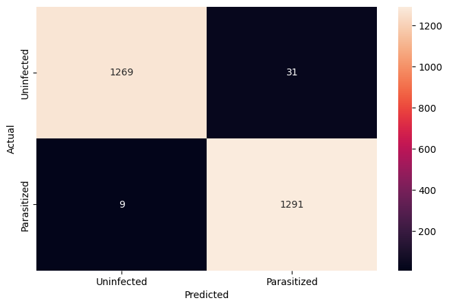

```python
pred = model1.predict(test_images)
pred = np.argmax(pred, axis = 1)
y_true = np.argmax(test_labels, axis = 1)

#Print classification report
report_model1 = classification_report(y_true, pred, output_dict=True)
print(classification_report(y_true, pred))

#Plotting the heatmap
cm = confusion_matrix(y_true, pred)
plt.figure(figsize = (8, 5))
sns.heatmap(cm, annot = True,  fmt = '.0f', xticklabels = ['Uninfected', 'Parasitized'], yticklabels =['Uninfected', 'Parasitized'] )
plt.ylabel('Actual')
plt.xlabel('Predicted')
plt.show()
```

**Plotting the train and the validation curves**

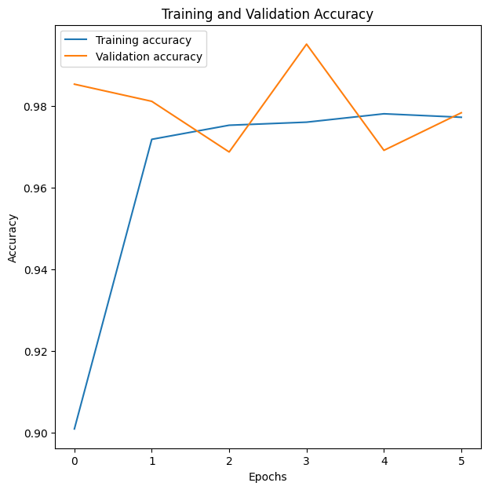

```python
plot_accuracy(history)
```

### **Think about it:**

Now let's build a model with LeakyRelu as the activation function

- Can the model performance be improved if we change our activation function to LeakyRelu?
- Can BatchNormalization improve our model?

Let us try to build a model using BatchNormalization and using LeakyRelu as our activation function.

### **Model 2 with Batch Normalization**

```python
backend.clear_session()

np.random.seed(42)
import random
random.seed(42)
tf.random.set_seed(42)
```

### **Building the Model**

```python
model2 = Sequential()

model2.add(Conv2D(filters=64, kernel_size=2, padding="same", input_shape=(64, 64, 3)))
model2.add(BatchNormalization())
model2.add(LeakyReLU(alpha=0.1))
model2.add(MaxPooling2D(pool_size=2))
model2.add(Dropout(0.2))

model2.add(Conv2D(filters=32, kernel_size=2, padding="same"))
model2.add(BatchNormalization())
model2.add(LeakyReLU(alpha=0.1))
model2.add(MaxPooling2D(pool_size=2))
model2.add(Dropout(0.2))

model2.add(Conv2D(filters=32, kernel_size=2, padding="same"))
model2.add(BatchNormalization())
model2.add(LeakyReLU(alpha=0.1))
model2.add(MaxPooling2D(pool_size=2))
model2.add(Dropout(0.2))

model2.add(Conv2D(filters=32, kernel_size=2, padding="same"))
model2.add(BatchNormalization())
model2.add(LeakyReLU(alpha=0.1))
model2.add(MaxPooling2D(pool_size=2))
model2.add(Dropout(0.2))

model2.add(GlobalAveragePooling2D())

model2.add(Dense(512))
model2.add(Dropout(0.4))

model2.add(Dense(2, activation="softmax"))

model2.summary()
```

```
Model: "sequential"
```

```
┏━━━━━━━━━━━━━━━━━━━━━━━━━━━━━━━━━━━━━━┳━━━━━━━━━━━━━━━━━━━━━━━━━━━━━┳━━━━━━━━━━━━━━━━━┓
┃ Layer (type)                         ┃ Output Shape                ┃         Param # ┃
┡━━━━━━━━━━━━━━━━━━━━━━━━━━━━━━━━━━━━━━╇━━━━━━━━━━━━━━━━━━━━━━━━━━━━━╇━━━━━━━━━━━━━━━━━┩
│ conv2d (Conv2D)                      │ (None, 64, 64, 64)          │             832 │
├──────────────────────────────────────┼─────────────────────────────┼─────────────────┤
│ batch_normalization                  │ (None, 64, 64, 64)          │             256 │
│ (BatchNormalization)                 │                             │                 │
├──────────────────────────────────────┼─────────────────────────────┼─────────────────┤
│ leaky_re_lu (LeakyReLU)              │ (None, 64, 64, 64)          │               0 │
├──────────────────────────────────────┼─────────────────────────────┼─────────────────┤
│ max_pooling2d (MaxPooling2D)         │ (None, 32, 32, 64)          │               0 │
├──────────────────────────────────────┼─────────────────────────────┼─────────────────┤
│ dropout (Dropout)                    │ (None, 32, 32, 64)          │               0 │
├──────────────────────────────────────┼─────────────────────────────┼─────────────────┤
│ conv2d_1 (Conv2D)                    │ (None, 32, 32, 32)          │           8,224 │
├──────────────────────────────────────┼─────────────────────────────┼─────────────────┤
│ batch_normalization_1                │ (None, 32, 32, 32)          │             128 │
│ (BatchNormalization)                 │                             │                 │
├──────────────────────────────────────┼─────────────────────────────┼─────────────────┤
│ leaky_re_lu_1 (LeakyReLU)            │ (None, 32, 32, 32)          │               0 │
├──────────────────────────────────────┼─────────────────────────────┼─────────────────┤
│ max_pooling2d_1 (MaxPooling2D)       │ (None, 16, 16, 32)          │               0 │
├──────────────────────────────────────┼─────────────────────────────┼─────────────────┤
│ dropout_1 (Dropout)                  │ (None, 16, 16, 32)          │               0 │
├──────────────────────────────────────┼─────────────────────────────┼─────────────────┤
│ conv2d_2 (Conv2D)                    │ (None, 16, 16, 32)          │           4,128 │
├──────────────────────────────────────┼─────────────────────────────┼─────────────────┤
│ batch_normalization_2                │ (None, 16, 16, 32)          │             128 │
│ (BatchNormalization)                 │                             │                 │
├──────────────────────────────────────┼─────────────────────────────┼─────────────────┤
│ leaky_re_lu_2 (LeakyReLU)            │ (None, 16, 16, 32)          │               0 │
├──────────────────────────────────────┼─────────────────────────────┼─────────────────┤
│ max_pooling2d_2 (MaxPooling2D)       │ (None, 8, 8, 32)            │               0 │
├──────────────────────────────────────┼─────────────────────────────┼─────────────────┤
│ dropout_2 (Dropout)                  │ (None, 8, 8, 32)            │               0 │
├──────────────────────────────────────┼─────────────────────────────┼─────────────────┤
│ conv2d_3 (Conv2D)                    │ (None, 8, 8, 32)            │           4,128 │
├──────────────────────────────────────┼─────────────────────────────┼─────────────────┤
│ batch_normalization_3                │ (None, 8, 8, 32)            │             128 │
│ (BatchNormalization)                 │                             │                 │
├──────────────────────────────────────┼─────────────────────────────┼─────────────────┤
│ leaky_re_lu_3 (LeakyReLU)            │ (None, 8, 8, 32)            │               0 │
├──────────────────────────────────────┼─────────────────────────────┼─────────────────┤
│ max_pooling2d_3 (MaxPooling2D)       │ (None, 4, 4, 32)            │               0 │
├──────────────────────────────────────┼─────────────────────────────┼─────────────────┤
│ dropout_3 (Dropout)                  │ (None, 4, 4, 32)            │               0 │
├──────────────────────────────────────┼─────────────────────────────┼─────────────────┤
│ global_average_pooling2d             │ (None, 32)                  │               0 │
│ (GlobalAveragePooling2D)             │                             │                 │
├──────────────────────────────────────┼─────────────────────────────┼─────────────────┤
│ dense (Dense)                        │ (None, 512)                 │          16,896 │
├──────────────────────────────────────┼─────────────────────────────┼─────────────────┤
│ dropout_4 (Dropout)                  │ (None, 512)                 │               0 │
├──────────────────────────────────────┼─────────────────────────────┼─────────────────┤
│ dense_1 (Dense)                      │ (None, 2)                   │           1,026 │
└──────────────────────────────────────┴─────────────────────────────┴─────────────────┘
```

```
 Total params: 35,874 (140.13 KB)
```

```
 Trainable params: 35,554 (138.88 KB)
```

```
 Non-trainable params: 320 (1.25 KB)
```

### **Compiling the model**

```python
model2.compile(loss = 'binary_crossentropy', optimizer = 'adam', metrics = ['accuracy'])
```

**Using callbacks**

```python
callbacks = [EarlyStopping(monitor = 'val_loss', patience = 2),
             ModelCheckpoint('.mdl_wts.keras', monitor = 'val_loss', save_best_only = True)]
```

**Fit and train the model**

```python
history = model2.fit(train_images, train_labels, batch_size = 32, callbacks = callbacks, validation_split = 0.2, epochs = 20, verbose = 1)
```

```
624/624 ━━━━━━━━━━━━━━━━━━━━ 25s 24ms/step - accuracy: 0.7988 - loss: 0.4295 - val_accuracy: 0.9996 - val_loss: 0.0296
624/624 ━━━━━━━━━━━━━━━━━━━━ 5s 9ms/step - accuracy: 0.9601 - loss: 0.1269 - val_accuracy: 0.9958 - val_loss: 0.0377
624/624 ━━━━━━━━━━━━━━━━━━━━ 6s 10ms/step - accuracy: 0.9660 - loss: 0.1070 - val_accuracy: 0.9958 - val_loss: 0.0499
```

**Plotting the train and validation accuracy**

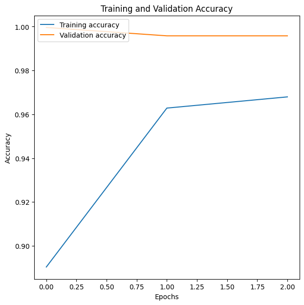

```python
plot_accuracy(history)
```

### **Evaluating the model**

```python
accuracy = model2.evaluate(test_images, test_labels, verbose = 1)
print('\n', 'Test_Accuracy:-', accuracy[1])
```

```
82/82 ━━━━━━━━━━━━━━━━━━━━ 2s 16ms/step - accuracy: 0.8982 - loss: 0.2924

 Test_Accuracy:- 0.9338461756706238
```

#### **Observations and insights:**

**Generate the classification report and confusion matrix**

```
82/82 ━━━━━━━━━━━━━━━━━━━━ 2s 14ms/step
              precision    recall  f1-score   support

           0       0.89      0.99      0.94      1300
           1       0.99      0.88      0.93      1300

    accuracy                           0.93      2600
   macro avg       0.94      0.93      0.93      2600
weighted avg       0.94      0.93      0.93      2600
```

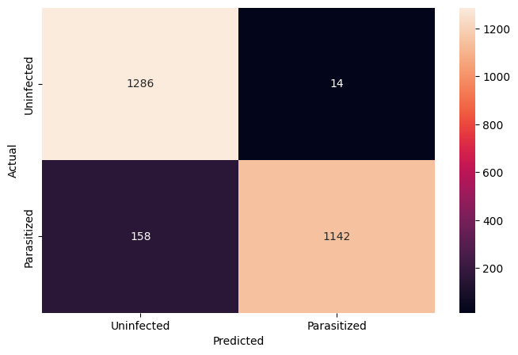

```python
pred = model2.predict(test_images)
pred = np.argmax(pred, axis = 1)
y_true = np.argmax(test_labels, axis = 1)

#Print classification report
report_model2 = classification_report(y_true, pred, output_dict=True)
print(classification_report(y_true, pred))

#Plotting the heatmap
cm = confusion_matrix(y_true, pred)
plt.figure(figsize = (8, 5))
sns.heatmap(cm, annot = True,  fmt = '.0f', xticklabels = ['Uninfected', 'Parasitized'], yticklabels =['Uninfected', 'Parasitized'] )
plt.ylabel('Actual')
plt.xlabel('Predicted')
plt.show()
```

### **Think About It :**

- Can we improve the model with Image Data Augmentation?
- References to image data augmentation can be seen below:
  - [Image Augmentation for Computer Vision](https://www.mygreatlearning.com/blog/understanding-data-augmentation/)
  - [How to Configure Image Data Augmentation in Keras?](https://machinelearningmastery.com/how-to-configure-image-data-augmentation-when-training-deep-learning-neural-networks/)

```python
backend.clear_session()

np.random.seed(42)
import random
random.seed(42)
tf.random.set_seed(42)
```

### **Use image data generator**

```python
from sklearn.model_selection import train_test_split

X_train, X_val, y_train, y_val = train_test_split(train_images, train_labels, test_size = 0.2, random_state = 42)

from tensorflow.keras.preprocessing.image import ImageDataGenerator

#Generating images
train_datagen = ImageDataGenerator(horizontal_flip = True, zoom_range = 0.5, rotation_range = 30)

val_datagen = ImageDataGenerator()

#Generating train_datagen
train_generator = train_datagen.flow(X_train, y_train, batch_size = 64, seed = 42, shuffle = True)

#Generating val_datagen
val_generator = val_datagen.flow(X_val, y_val,batch_size = 64, seed = 42, shuffle = True)
```

### **Think About It :**

- Check if the performance of the model can be improved by changing different parameters in the ImageDataGenerator.

#### **Visualizing Augmented images**

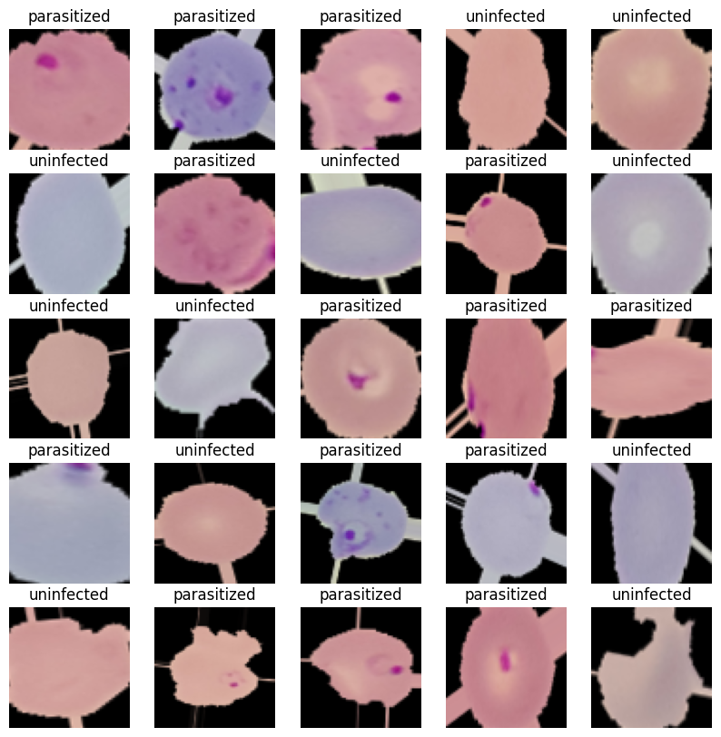

```python
images, labels = next(train_generator)


fig, axes = plt.subplots(5, 5, figsize = (10, 10))

fig.set_size_inches(10, 10)
for (image, label, ax) in zip(images, labels, axes.flatten()):

    ax.imshow(image)

    if label[1] == 1:

        ax.set_title('parasitized')

    else:

        ax.set_title('uninfected')

    ax.axis('off')
```

#### **Observations and insights:**

- Data augmentation can prevent overfittting
- By modifying our already owned pictures (zooming in or out, rotating, etc), our dataset becomes more diverse, helping our model to perform better on unseen data

### **Building the Model**

```python
#Increasing the number of filter progressively, changing kernel_size, adding kernel_regularizer

model3 = Sequential()

model3.add(Conv2D(filters = 64, kernel_size = 3, padding = "same", input_shape = (64, 64, 3)))

model3.add(LeakyReLU(alpha=0.1))

model3.add(BatchNormalization())

model3.add(MaxPooling2D(pool_size = 2))

model3.add(Dropout(0.2))

model3.add(Conv2D(filters = 32, kernel_size = 3, padding = "same"))

model3.add(LeakyReLU(alpha=0.1))

model3.add(MaxPooling2D(pool_size = 2))

model3.add(Dropout(0.2))

model3.add(Conv2D(filters = 32, kernel_size = 3, padding = "same"))

model3.add(LeakyReLU(alpha=0.1))

model3.add(MaxPooling2D(pool_size = 2))

model3.add(Dropout(0.2))

model3.add(Conv2D(filters = 32, kernel_size = 3, padding = "same"))

model3.add(LeakyReLU(alpha=0.1))

model3.add(MaxPooling2D(pool_size = 2))

model3.add(Dropout(0.2))

model3.add(GlobalAveragePooling2D())

model3.add(Dense(512, kernel_regularizer=regularizers.l2(0.001)))

model3.add(Dropout(0.4))

model3.add(Dense(2, activation = "softmax"))

model3.summary()
```

```
Model: "sequential"
```

```
┏━━━━━━━━━━━━━━━━━━━━━━━━━━━━━━━━━━━━━━┳━━━━━━━━━━━━━━━━━━━━━━━━━━━━━┳━━━━━━━━━━━━━━━━━┓
┃ Layer (type)                         ┃ Output Shape                ┃         Param # ┃
┡━━━━━━━━━━━━━━━━━━━━━━━━━━━━━━━━━━━━━━╇━━━━━━━━━━━━━━━━━━━━━━━━━━━━━╇━━━━━━━━━━━━━━━━━┩
│ conv2d (Conv2D)                      │ (None, 64, 64, 64)          │           1,792 │
├──────────────────────────────────────┼─────────────────────────────┼─────────────────┤
│ leaky_re_lu (LeakyReLU)              │ (None, 64, 64, 64)          │               0 │
├──────────────────────────────────────┼─────────────────────────────┼─────────────────┤
│ batch_normalization                  │ (None, 64, 64, 64)          │             256 │
│ (BatchNormalization)                 │                             │                 │
├──────────────────────────────────────┼─────────────────────────────┼─────────────────┤
│ max_pooling2d (MaxPooling2D)         │ (None, 32, 32, 64)          │               0 │
├──────────────────────────────────────┼─────────────────────────────┼─────────────────┤
│ dropout (Dropout)                    │ (None, 32, 32, 64)          │               0 │
├──────────────────────────────────────┼─────────────────────────────┼─────────────────┤
│ conv2d_1 (Conv2D)                    │ (None, 32, 32, 32)          │          18,464 │
├──────────────────────────────────────┼─────────────────────────────┼─────────────────┤
│ leaky_re_lu_1 (LeakyReLU)            │ (None, 32, 32, 32)          │               0 │
├──────────────────────────────────────┼─────────────────────────────┼─────────────────┤
│ max_pooling2d_1 (MaxPooling2D)       │ (None, 16, 16, 32)          │               0 │
├──────────────────────────────────────┼─────────────────────────────┼─────────────────┤
│ dropout_1 (Dropout)                  │ (None, 16, 16, 32)          │               0 │
├──────────────────────────────────────┼─────────────────────────────┼─────────────────┤
│ conv2d_2 (Conv2D)                    │ (None, 16, 16, 32)          │           9,248 │
├──────────────────────────────────────┼─────────────────────────────┼─────────────────┤
│ leaky_re_lu_2 (LeakyReLU)            │ (None, 16, 16, 32)          │               0 │
├──────────────────────────────────────┼─────────────────────────────┼─────────────────┤
│ max_pooling2d_2 (MaxPooling2D)       │ (None, 8, 8, 32)            │               0 │
├──────────────────────────────────────┼─────────────────────────────┼─────────────────┤
│ dropout_2 (Dropout)                  │ (None, 8, 8, 32)            │               0 │
├──────────────────────────────────────┼─────────────────────────────┼─────────────────┤
│ conv2d_3 (Conv2D)                    │ (None, 8, 8, 32)            │           9,248 │
├──────────────────────────────────────┼─────────────────────────────┼─────────────────┤
│ leaky_re_lu_3 (LeakyReLU)            │ (None, 8, 8, 32)            │               0 │
├──────────────────────────────────────┼─────────────────────────────┼─────────────────┤
│ max_pooling2d_3 (MaxPooling2D)       │ (None, 4, 4, 32)            │               0 │
├──────────────────────────────────────┼─────────────────────────────┼─────────────────┤
│ dropout_3 (Dropout)                  │ (None, 4, 4, 32)            │               0 │
├──────────────────────────────────────┼─────────────────────────────┼─────────────────┤
│ global_average_pooling2d             │ (None, 32)                  │               0 │
│ (GlobalAveragePooling2D)             │                             │                 │
├──────────────────────────────────────┼─────────────────────────────┼─────────────────┤
│ dense (Dense)                        │ (None, 512)                 │          16,896 │
├──────────────────────────────────────┼─────────────────────────────┼─────────────────┤
│ dropout_4 (Dropout)                  │ (None, 512)                 │               0 │
├──────────────────────────────────────┼─────────────────────────────┼─────────────────┤
│ dense_1 (Dense)                      │ (None, 2)                   │           1,026 │
└──────────────────────────────────────┴─────────────────────────────┴─────────────────┘
```

```
 Total params: 56,930 (222.38 KB)
```

```
 Trainable params: 56,802 (221.88 KB)
```

```
 Non-trainable params: 128 (512.00 B)
```

**Compiling**

```python
adam = optimizers.Adam(learning_rate=0.001)
model3.compile(loss = 'binary_crossentropy', optimizer = 'adam', metrics = ['accuracy'])
```

**Using Callbacks**

```python
callbacks = [EarlyStopping(monitor = 'val_loss', patience = 2),
             ModelCheckpoint('.mdl_wts.keras', monitor = 'val_loss', save_best_only = True)]
```

**Fit and Train the model**

```python
history = model3.fit(train_images, train_labels, batch_size = 32, callbacks = callbacks, validation_split = 0.2, epochs = 20, verbose = 1)
```

```
624/624 ━━━━━━━━━━━━━━━━━━━━ 21s 23ms/step - accuracy: 0.8047 - loss: 0.4233 - val_accuracy: 0.9990 - val_loss: 0.0940
624/624 ━━━━━━━━━━━━━━━━━━━━ 9s 12ms/step - accuracy: 0.9645 - loss: 0.1101 - val_accuracy: 0.9972 - val_loss: 0.0579
624/624 ━━━━━━━━━━━━━━━━━━━━ 10s 13ms/step - accuracy: 0.9699 - loss: 0.0944 - val_accuracy: 0.9958 - val_loss: 0.0469
624/624 ━━━━━━━━━━━━━━━━━━━━ 6s 10ms/step - accuracy: 0.9729 - loss: 0.0836 - val_accuracy: 0.9900 - val_loss: 0.0780
624/624 ━━━━━━━━━━━━━━━━━━━━ 13s 14ms/step - accuracy: 0.9731 - loss: 0.0845 - val_accuracy: 0.9820 - val_loss: 0.0820
```

### **Evaluating the model**

**Plot the train and validation accuracy**

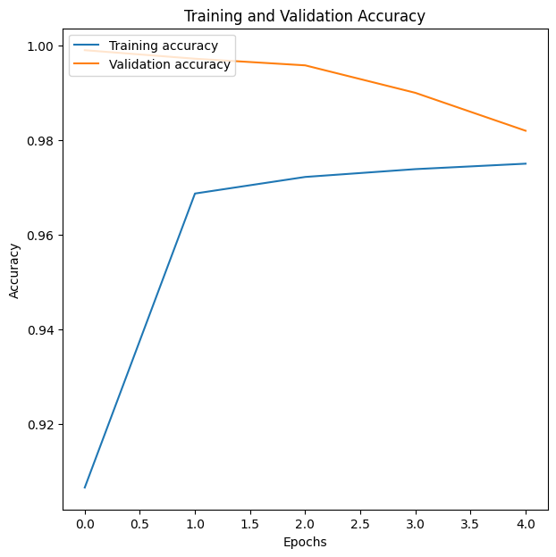

```python
plot_accuracy(history)
```

```python
accuracy = model3.evaluate(test_images, test_labels, verbose = 1)
print('\n', 'Test_Accuracy:-', accuracy[1])
```

```
82/82 ━━━━━━━━━━━━━━━━━━━━ 3s 14ms/step - accuracy: 0.9857 - loss: 0.0421

 Test_Accuracy:- 0.9850000143051147
```

**Plotting the classification report and confusion matrix**

```
82/82 ━━━━━━━━━━━━━━━━━━━━ 1s 13ms/step
              precision    recall  f1-score   support

           0       0.99      0.98      0.98      1300
           1       0.98      0.99      0.99      1300

    accuracy                           0.98      2600
   macro avg       0.99      0.98      0.98      2600
weighted avg       0.99      0.98      0.98      2600
```

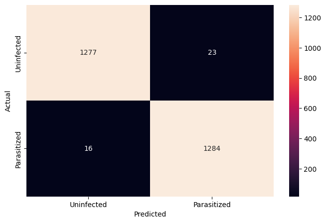

```python
pred = model3.predict(test_images)
pred = np.argmax(pred, axis = 1)
y_true = np.argmax(test_labels, axis = 1)

#Print classification report
report_model3 = classification_report(y_true, pred, output_dict=True)
print(classification_report(y_true, pred))

#Plotting the heatmap
cm = confusion_matrix(y_true, pred)
plt.figure(figsize = (8, 5))
sns.heatmap(cm, annot = True,  fmt = '.0f', xticklabels = ['Uninfected', 'Parasitized'], yticklabels =['Uninfected', 'Parasitized'] )
plt.ylabel('Actual')
plt.xlabel('Predicted')
plt.show()
```

**Now, let us try to use a pretrained model like VGG16 and check how it performs on our data.**

### **Pre-trained model (VGG16)**

- Import VGG16 network upto any layer you choose
- Add Fully Connected Layers on top of it

```python
from tensorflow.keras import backend
backend.clear_session()

np.random.seed(42)
import random
random.seed(42)
tf.random.set_seed(42)
```

```python
#Importing VGG16
from tensorflow.keras import Model

from tensorflow.keras.applications.vgg16 import VGG16

vgg = VGG16(weights = 'imagenet', include_top = False, input_shape = (64, 64, 3))

vgg.summary()
```

```
Downloading data from https://storage.googleapis.com/tensorflow/keras-applications/vgg16/vgg16_weights_tf_dim_ordering_tf_kernels_notop.h5
58889256/58889256 ━━━━━━━━━━━━━━━━━━━━ 4s 0us/step
```

```
Model: "vgg16"
```

```
┏━━━━━━━━━━━━━━━━━━━━━━━━━━━━━━━━━━━━━━┳━━━━━━━━━━━━━━━━━━━━━━━━━━━━━┳━━━━━━━━━━━━━━━━━┓
┃ Layer (type)                         ┃ Output Shape                ┃         Param # ┃
┡━━━━━━━━━━━━━━━━━━━━━━━━━━━━━━━━━━━━━━╇━━━━━━━━━━━━━━━━━━━━━━━━━━━━━╇━━━━━━━━━━━━━━━━━┩
│ input_layer (InputLayer)             │ (None, 64, 64, 3)           │               0 │
├──────────────────────────────────────┼─────────────────────────────┼─────────────────┤
│ block1_conv1 (Conv2D)                │ (None, 64, 64, 64)          │           1,792 │
├──────────────────────────────────────┼─────────────────────────────┼─────────────────┤
│ block1_conv2 (Conv2D)                │ (None, 64, 64, 64)          │          36,928 │
├──────────────────────────────────────┼─────────────────────────────┼─────────────────┤
│ block1_pool (MaxPooling2D)           │ (None, 32, 32, 64)          │               0 │
├──────────────────────────────────────┼─────────────────────────────┼─────────────────┤
│ block2_conv1 (Conv2D)                │ (None, 32, 32, 128)         │          73,856 │
├──────────────────────────────────────┼─────────────────────────────┼─────────────────┤
│ block2_conv2 (Conv2D)                │ (None, 32, 32, 128)         │         147,584 │
├──────────────────────────────────────┼─────────────────────────────┼─────────────────┤
│ block2_pool (MaxPooling2D)           │ (None, 16, 16, 128)         │               0 │
├──────────────────────────────────────┼─────────────────────────────┼─────────────────┤
│ block3_conv1 (Conv2D)                │ (None, 16, 16, 256)         │         295,168 │
├──────────────────────────────────────┼─────────────────────────────┼─────────────────┤
│ block3_conv2 (Conv2D)                │ (None, 16, 16, 256)         │         590,080 │
├──────────────────────────────────────┼─────────────────────────────┼─────────────────┤
│ block3_conv3 (Conv2D)                │ (None, 16, 16, 256)         │         590,080 │
├──────────────────────────────────────┼─────────────────────────────┼─────────────────┤
│ block3_pool (MaxPooling2D)           │ (None, 8, 8, 256)           │               0 │
├──────────────────────────────────────┼─────────────────────────────┼─────────────────┤
│ block4_conv1 (Conv2D)                │ (None, 8, 8, 512)           │       1,180,160 │
├──────────────────────────────────────┼─────────────────────────────┼─────────────────┤
│ block4_conv2 (Conv2D)                │ (None, 8, 8, 512)           │       2,359,808 │
├──────────────────────────────────────┼─────────────────────────────┼─────────────────┤
│ block4_conv3 (Conv2D)                │ (None, 8, 8, 512)           │       2,359,808 │
├──────────────────────────────────────┼─────────────────────────────┼─────────────────┤
│ block4_pool (MaxPooling2D)           │ (None, 4, 4, 512)           │               0 │
├──────────────────────────────────────┼─────────────────────────────┼─────────────────┤
│ block5_conv1 (Conv2D)                │ (None, 4, 4, 512)           │       2,359,808 │
├──────────────────────────────────────┼─────────────────────────────┼─────────────────┤
│ block5_conv2 (Conv2D)                │ (None, 4, 4, 512)           │       2,359,808 │
├──────────────────────────────────────┼─────────────────────────────┼─────────────────┤
│ block5_conv3 (Conv2D)                │ (None, 4, 4, 512)           │       2,359,808 │
├──────────────────────────────────────┼─────────────────────────────┼─────────────────┤
│ block5_pool (MaxPooling2D)           │ (None, 2, 2, 512)           │               0 │
└──────────────────────────────────────┴─────────────────────────────┴─────────────────┘
```

```
 Total params: 14,714,688 (56.13 MB)
```

```
 Trainable params: 14,714,688 (56.13 MB)
```

```
 Non-trainable params: 0 (0.00 B)
```

```python
transfer_layer = vgg.get_layer('block3_pool')
```

```python
vgg.trainable = False
```

```python
model4 = Sequential()
model4.add(vgg)
model4.add(Flatten())
model4.add(Dense(512, activation = 'relu'))
model4.add(Dropout(0.4))
model4.add(Dense(2, activation = 'softmax'))
```

### **Compiling the model**

```python
model4.compile(loss = 'binary_crossentropy', optimizer = tf.keras.optimizers.Adamax(learning_rate = 0.0005), metrics = ['accuracy'])
```

**using callbacks**

```python
callbacks = [EarlyStopping(monitor = 'val_loss', patience = 2),
             ModelCheckpoint('.mdl_wts.keras', monitor = 'val_loss', save_best_only = True)]
```

**Fit and Train the model**

```python
history = model4.fit(train_images, train_labels, batch_size = 32, callbacks = callbacks, validation_split = 0.2, epochs = 20, verbose = 1)
```

```
624/624 ━━━━━━━━━━━━━━━━━━━━ 28s 34ms/step - accuracy: 0.8532 - loss: 0.3374 - val_accuracy: 0.9052 - val_loss: 0.2779
624/624 ━━━━━━━━━━━━━━━━━━━━ 28s 21ms/step - accuracy: 0.9259 - loss: 0.1912 - val_accuracy: 0.9335 - val_loss: 0.2188
624/624 ━━━━━━━━━━━━━━━━━━━━ 13s 20ms/step - accuracy: 0.9370 - loss: 0.1678 - val_accuracy: 0.9281 - val_loss: 0.2230
624/624 ━━━━━━━━━━━━━━━━━━━━ 13s 21ms/step - accuracy: 0.9414 - loss: 0.1544 - val_accuracy: 0.9421 - val_loss: 0.1894
624/624 ━━━━━━━━━━━━━━━━━━━━ 12s 20ms/step - accuracy: 0.9453 - loss: 0.1473 - val_accuracy: 0.9513 - val_loss: 0.1557
624/624 ━━━━━━━━━━━━━━━━━━━━ 22s 22ms/step - accuracy: 0.9482 - loss: 0.1416 - val_accuracy: 0.9457 - val_loss: 0.1690
624/624 ━━━━━━━━━━━━━━━━━━━━ 14s 23ms/step - accuracy: 0.9482 - loss: 0.1386 - val_accuracy: 0.9473 - val_loss: 0.1611
```

**Plot the train and validation accuracy**

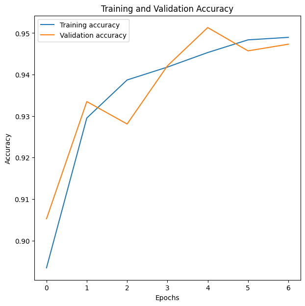

```python
plot_accuracy(history)
```

### **Observations and insights:**

- By epoch 5 both accuracies converge around 95%, this means that the model is learning and generalizing well, there is no significant overfitting

### **Evaluating the model**

```python
accuracy = model4.evaluate(test_images, test_labels, verbose = 1)
print('\n', 'Test_Accuracy:-', accuracy[1])
```

```
82/82 ━━━━━━━━━━━━━━━━━━━━ 5s 44ms/step - accuracy: 0.9536 - loss: 0.1074

 Test_Accuracy:- 0.9350000023841858
```

**Plotting the classification report and confusion matrix**

```
82/82 ━━━━━━━━━━━━━━━━━━━━ 3s 23ms/step
              precision    recall  f1-score   support

           0       0.97      0.90      0.93      1300
           1       0.91      0.97      0.94      1300

    accuracy                           0.94      2600
   macro avg       0.94      0.94      0.93      2600
weighted avg       0.94      0.94      0.93      2600
```

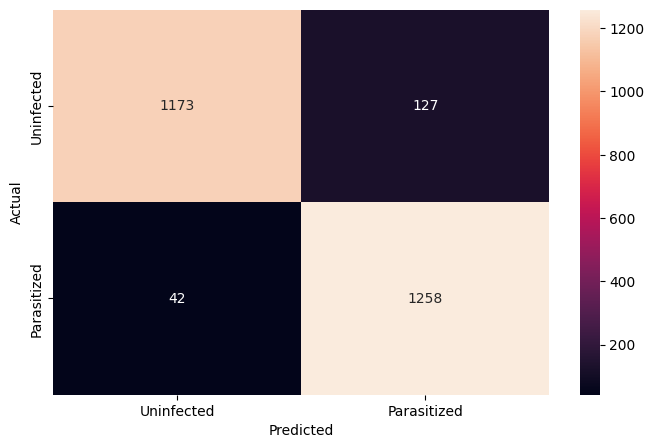

```python
pred = model4.predict(test_images)
pred = np.argmax(pred, axis = 1)
y_true = np.argmax(test_labels, axis = 1)

#Print classification report
report_model4 = classification_report(y_true, pred, output_dict=True)
print(classification_report(y_true, pred))

#Plotting the heatmap
cm = confusion_matrix(y_true, pred)
plt.figure(figsize = (8, 5))
sns.heatmap(cm, annot = True,  fmt = '.0f', xticklabels = ['Uninfected', 'Parasitized'], yticklabels =['Uninfected', 'Parasitized'] )
plt.ylabel('Actual')
plt.xlabel('Predicted')
plt.show()
```

### **Think about it:[**](https://)

- What observations and insights can be drawn from the confusion matrix and classification report?
- Choose the model with the best accuracy scores from all the above models and save it as a final model.